# Climate stability methods

**Fordham, D., Brown, S., Wigley, T., Rahbek, C., 2019. Cradles of diversity: unlikely relics of regional climate stability. *Current Biology* (in press)**

The R code necessary to re-produce the analysis is provided at the bottom of the file.

### Extended Methods

Continuous paleoclimate simulations of gridded monthly-mean temperature at the surface (TS) for the period 21,000 BP to 100 BP were accessed from the TRaCE21ka experiment<sup>1</sup> using PaleoView<sup>2</sup>. Multi-century pre-industrial control runs of annual-mean TS for 18 different AOGCMs (Table 1) were retrieved from the Coupled Model Intercomparison Project Phase 5<sup>3</sup> and resampled to a common 2.5° x 2.5° grid using bilinear interpolation. Bilinear interpolation was chosen because (i) the source and destination grids were rectilinear, (ii) temperature varies smoothly spatially, and (iii) bilinear interpolation reasonably retains the integrity and limitations of the original model output data, where orography is highly smoothed relative to the real-world<sup>4</sup>.

Pre-industrial control runs are multi-century unforced climate simulations, where the initial model conditions are set based on atmospheric gas concentrations pre-wide-scale industrialisation (c. 1750 - 1850 CE), combined with non-evolving boundary conditions<sup>3</sup>. We elected to use only the first realisation (r1i1p1) from each AOGCM for the pre-industrial control runs because all models, with the exception of the Community Climate System Model ver. 4 (CCSM4)<sup>5</sup>, only had a single realisation for pre-industrial control conditions. Furthermore, the additional pre-industrial realisations (r2i1p1 and r3i1p1) for the CCSM4 model ran for considerably shorter periods: 156 and 120 years (Table 1). These pre-industrial control runs were used as a baseline for determining centuries of large changes in global-mean temperature (see below).

##### *Identifying ‘extreme’ natural periods of global climate change.*

We used multi-century pre-industrial control runs from the AOGCMs to estimate internally-generated natural variability in area-weighted global-mean trend magnitudes in TS(°C/year)<sup>6</sup> using generalised least squares (GLS) regression and maximally (1-year) overlapping windows i.e., a 100-year moving window with a 1-year step between windows. GLS regression models were generated using the nlme package for R<sup>7</sup>. Trends for the 18 AOGCMs were calculated using area-weighted global-mean temperatures based on the slope of the GLS model. An AR(1) error structure was chosen to minimise any effect of temporal auto-correlation in the model residuals<sup>7</sup>. The resulting global pre-industrial model trends (i.e., the slope of the regression against time) for TS were used to generate a multi-model empirical cumulative distribution function (CDF) using unsigned (i.e. absolute) trends (Figure 1). Because the number of years varied between pre-industrial control runs from different AOGCMs (Table 1) we used a bootstrap procedure to ensure that all models had equal weights in the CDF. This involved randomly selecting 141 centuries from each model (with replacement) - 141 is the minimum number of maximally overlapping century-length windows across all models. The bootstrap procedure was repeated 1000 times. Centuries having extreme trends were defined as those where the trend exceeded the 90th percentile of the multi-model control-run CDF. The 90th percentile is commonly used in climate change research to identify extreme events<sup>8</sup><sup>,</sup><sup>9</sup>.

We applied the 90th percentile trend threshold of the multi-model control-run CDF to the time series of area-weighted global-mean paleoclimate trends (based on maximal overlapping windows) to identify specific centuries of extreme change in global-mean temperature during the period 21,000 BP to 100 BP. We then subset the time series of paleoclimate simulations based on these periods of extreme change in area-weighted global-mean temperature. In doing so, ‘local’ measures of trend and variability (i.e., at the grid cell) were constrained to centuries of unusually high trends in global-mean temperature.

To check that our definition of extreme centuries of change in global-mean temperature was appropriate, we determined the amount of time a millennium was considered ‘extreme’. We did this by calculating the % of time that a millennium was characterised by trends $\ge$ 90th percentile of the control run trends (Figure 3). This confirmed that known large-scale climatic events during the last deglaciation (e.g. Bølling-Allerød, Younger Dryas, Holocene climate optimum etc.) were correctly identified as periods of extreme climate change in our analysis. We also examined the trend in global-mean temperature through time (Figure 3).

##### *Mapping past climate stability*

We calculated the median values of the century trends and variability about the trends for each grid cell for the periods of rapid change in global-mean temperature from 21,000 BP to 100 BP. We then mapped cells along a gradient of climate stability for land and ocean realms separately. The use of both trend and variability combines information about low frequency (trend) and high frequency (SD) variability. We classified cells according to eight levels of climate stability, ranging from ‘extremely stable’ to ‘extremely unstable’: (i) $\le$ 10th percentile of both trend and variability; (ii) $\gt$ 10th and $\le$ 25th percentile of both trend and variability; (iii) $\gt$ 25th and $\le$ 50th percentile of both trend and variability; (iv) $\le$ 50th percentile of trend and $\ge$ 50th percentile of variability; (v) $\ge$ 50th percentile of trend and $\le$ 50th percentile of variability; (vi) $\ge$ 50th and $\lt$ 75th percentile of both trend and variability; (vii) $\ge$ 75th and $\lt$ 90th percentile of both trend and variability; (viii) $\ge$ 90th percentile of both trend and variability.

### Figures

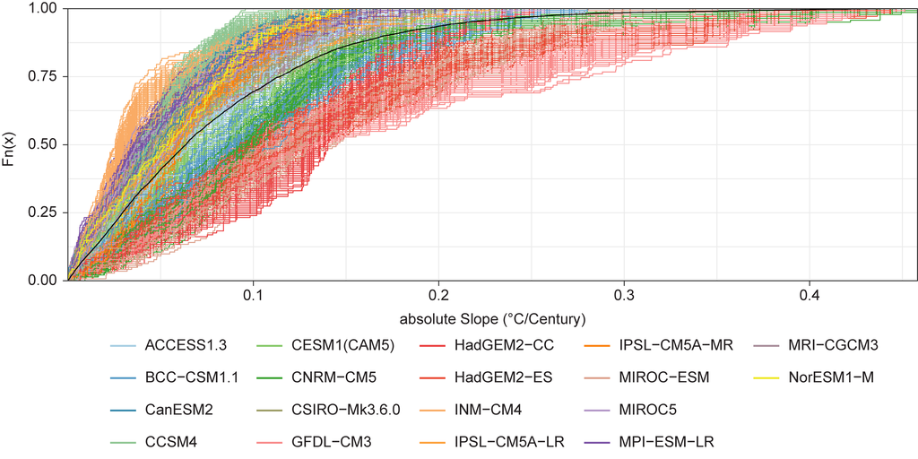

Figure 1: Cumulative Distribution Functions (CDFs) of trends in global-mean temperature for the pre-industrial CMIP5 control runs. Different colours represent the bootstrap replicates for each of the different models; the black line represents the mean of all the CDFs for each model bootstrap. Trends were calculated using a 100-year moving window with a 1-year step between windows.

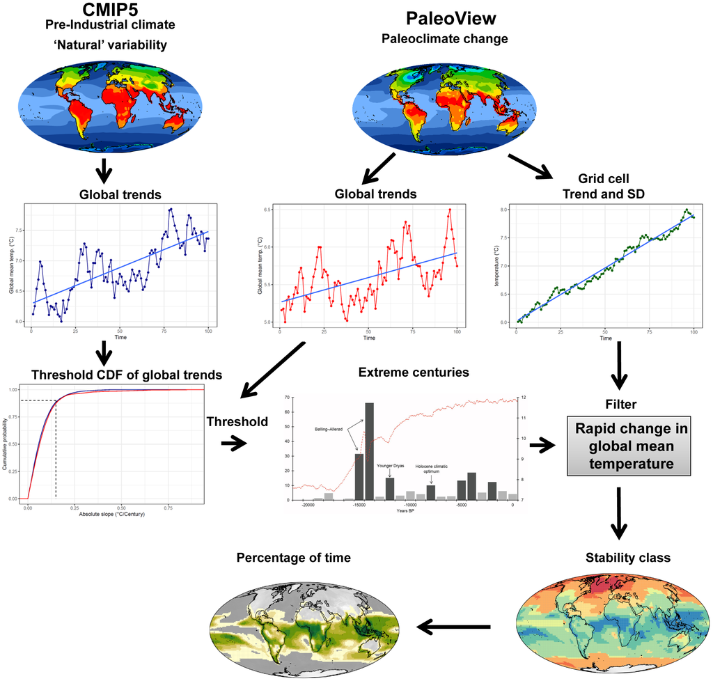

Figure 2: Workflow for estimating percentage of time spent in stable and extremely stable climates. CMIP5 pre-industrial control runs were used to estimate century trends in annual global mean temperature under conditions of natural variability focused on 100BP (1850 AD). The 90th percentile was used to calculate a threshold for identifying the most extreme century trends in global mean temperature for pre-industrial control runs. Century trends in annual global mean temperature and century trends and SD in annual grid cell mean temperature were generated for the last 21,000 using data from PaleoView. The threshold (90th percentile) for extreme century trends in global mean temperature for pre-industrial control runs was applied to the PaleoView estimates to identify centuries of rapid change (extreme centuries) in the past. These centuries were used to filter the time series of paleoclimate simulations of grid cell trends and SD, such that for each century of rapid change in global mean temperature, classes of climate stability were derived and the percentage of time a grid cell spent in a given stability class was calculated for all extreme centuries.

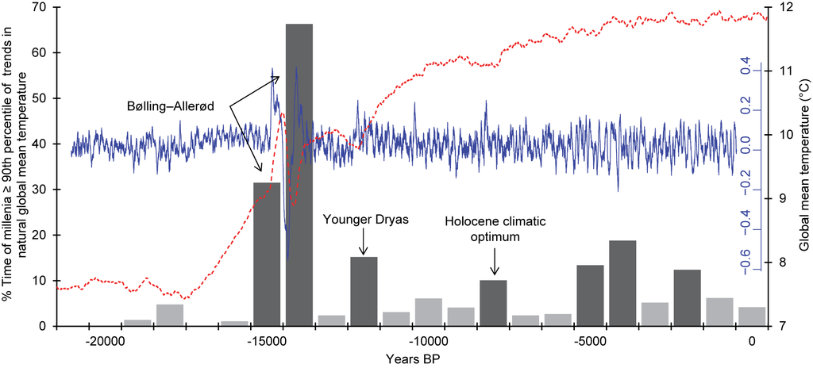

Figure 3: Percentage of time spent in ‘extreme’ conditions of global climate change defined as having century timescale trend magnitudes $\ge$ 90th percentile of the bootstrapped pre-industrial control-run trend magnitudes in global-mean temperature. The primary Y-axis and the vertical bars show the amount of time in a given millennium (X-axis) when the trend in global mean temperature is $\ge$ the cut-off threshold. Darker bars show millennia where centuries of unusually high trends in global mean temperatures occurred in $\gt$ 10% of the millennia. The secondary (right hand) Y-axis and the dashed red line shows the global-mean temperature from the TraCE-21ka dataset (°C). The blue line shows the slope for the linear trend for the global-mean temperature from the TraCE-21ka dataset (°C per year). Major climatic events are shown with arrows.

### Tables

Table S1: The 18 models used for the analysis of ‘natural’ trends under the pre-industrial control runs

| Model | Institution(s) | Lat | Long | Number of years |
| --- | --- | --- | --- | --- |
| ACCESS 1.3 | Commonwealth Scientific and Industrial Research Organisation / Bureau of Meteorology | 1.9 | 1.2 | 500 |
| BCC-CSM1.1 | Beijing Climate Center, China Meteorological Administration | 2.8 | 2.8 | 500 |
| CanESM2 | Canadian Centre for Climate Modelling and Analysis | 2.8 | 2.8 | 996 |
| CCSM4 | National Center for Atmospheric Research | 0.9 | 1.3 | 1,051 |
| CESM1(CAM5) | National Center for Atmospheric Research | 0.9 | 1.3 | 320 |
| CNRM-CM5 | Centre National de Recherches Meteorologiques / Centre Europeen de Recherche et Formation Avancees en Calcul Scientifique | 1.4 | 1.4 | 850 |
| CSIRO-Mk3.6.0 | Commonwealth Scientific and Industrial Research Organisation / Queensland Climate Change Centre of Excellence | 1.9 | 1.9 | 500 |
| GFDL-CM3 | National Oceanic and Atmospheric Administration Office of Oceanic and Atmospheric Research - Geophysical Fluid Dynamics Laboratory | 2.0 | 2.5 | 500 |
| HadGEM2-CC | Met Office Hadley Centre | 1.3 | 1.9 | 240 |
| HadGEM2-ES | Met Office Hadley Centre | 1.3 | 1.9 | 575 |
| INM-CM4 | Institute for Numerical Mathematics | 1.5 | 2.0 | 500 |
| IPSL-CM5A-LR | Institut Pierre-Simon Laplace | 1.9 | 3.8 | 1,000 |
| IPSL-CM5A-MR | Institut Pierre-Simon Laplace | 1.3 | 2.5 | 300 |
| MIROC5 | Atmosphere and Ocean Research Institute (The University of Tokyo), National Institute for Environmental Studies / Japan Agency for Marine-Earth Science and Technology | 1.4 | 1.4 | 670 |
| MIROC-ESM | Japan Agency for Marine-Earth Science and Technology, Atmosphere and Ocean Research Institute (The University of Tokyo) / National Institute for Environmental Studies | 2.8 | 2.8 | 630 |
| MPI-ESM-LR | Max Planck Institute for Meteorology | 1.9 | 1.9 | 1,000 |
| MRI-CGCM3 | Meteorological Research Institute | 1.1 | 1.1 | 500 |
| NorESM1-M | Norwegian Climate Centre | 1.9 | 2.5 | 501 |

### References

**1** Liu, Z., Otto-Bliesner, B.L., He, F., Brady, E.C., Tomas, R., Clark, P.U., Carlson, A.E., Lynch-Stieglitz, J., Curry, W., Brook, E., et al. (2009). Transient Simulation of Last Deglaciation with a New Mechanism for Bølling-Allerød Warming. Science 325, 310-314.$\hookleftarrow$

**2** Fordham, D.A., Saltré, F., Haythorne, S., Wigley, T.M.L., Otto-Bliesner, B.L., Chan, K., and Brook, B.W. (2017). PaleoView: A tool for generating continuous climate projections spanning the last 21,000 years at regional and global scales Ecography 40, 1348-1358.$\hookleftarrow$

**3** Taylor, K.E., Stouffer, R.J., and Meehl, G.A. (2011). An Overview of CMIP5 and the Experiment Design. Bulletin of the American Meteorological Society 93, 485-498.$\hookleftarrow$

**4** Fordham, D.A., Saltre, F., Haythorne, S., Wigley, T.M.L., Otto-Bliesner, B.L., Chan, K.C., and Brook, B.W. (2017). PaleoView: a tool for generating continuous climate projections spanning the last 21 000 years at regional and global scales. Ecography 40, 1348-1358.$\hookleftarrow$

**5** Gent, P.R., Danabasoglu, G., Donner, L.J., Holland, M.M., Hunke, E.C., Jayne, S.R., Lawrence, D.M., Neale, R.B., Rasch, P.J., Vertenstein, M., et al. (2011). The Community Climate System Model Version 4. Journal of Climate 24, 4973-4991.$\hookleftarrow$

**6** Gent, P.R., Danabasoglu, G., Donner, L.J., Holland, M.M., Hunke, E.C., Jayne, S.R., Lawrence, D.M., Neale, R.B., Rasch, P.J., Vertenstein, M., et al. (2011). The Community Climate System Model Version 4. Journal of Climate 24, 4973-4991.$\hookleftarrow$

**7** Pinheiro J, Bates D, DebRoy S, Sarkar D, and R Core Team (2017). nlme: Linear and Nonliner Mixed Effects Models. R package version 3.1-131$\hookleftarrow$

**8** Harris, R.M.B., Beaumont, L.J., Vance, T.R., Tozer, C.R., Remenyi, T.A., Perkins-Kirkpatrick, S.E., Mitchell, P.J., Nicotra, A.B., McGregor, S., Andrew, N.R., et al. (2018). Biological responses to the press and pulse of climate trends and extreme events. Nature Climate Change 8, 579-587$\hookleftarrow$

**9** Zhang, X., Alexander, L., Hegerl, G.C., Jones, P., Tank, A.K., Peterson, T.C., Trewin, B., and Zwiers, F.W. (2011). Indices for monitoring changes in extremes based on daily temperature and precipitation data. WIREs Clim Change 2, 851-870$\hookleftarrow$

**10** Nadeau, C.P., Urban, M.C., and Bridle, J.R. (2017). Coarse climate change projections for species living in a fine-scaled world. Global Change Biology 23, 12-24.$\hookleftarrow$

**11** Hao, Z., AghaKouchak, A., and Phillips, T.J. (2013). Changes in concurrent monthly precipitation and temperature extremes. Environmental Research Letters 8, 034014$\hookleftarrow$

### R Code

Code used to identify stable cells and perform the sensitivity analysis

```r
library(tidyverse)
library(gtools)
library(raster)
library(sf)
library(doParallel)

# load in the trace-21ka windows considered extremely unstable
load("./RObjects/unstableWindows.Rdata", verbose = TRUE)

# Calculate the amount of time that a cell is considered "stable" inside unstable windows

# Directory to trends
palDir <- "./path/to/trace/trends/"

# Trend
trendFiles <- mixedsort(
  list.files(palDir, "_TrendStand.grd$", full.names = TRUE),
  decreasing = TRUE
)
head(trendFiles)
tail(trendFiles)

# Stack. Files are single band and identical so can use stack(x, quick = TRUE)
trendStack <- raster::stack(trendFiles, quick = TRUE)
trendStack <- setZ(trendStack,
                   z = seq(-21000, by = 1, length.out = nlayers(trendStack)),
                   name = "Years BP")
names(trendStack) <- paste0("BP_", sub("-", "", getZ(trendStack)))
trendStack

# subset the trend stack to the extreme centuries of interest
trendStack <- trendStack[[unstableCents]]

# Variability
varFiles <- mixedsort(
  list.files(palDir, "Variability_.*grd$", full.names = TRUE),
  decreasing = TRUE
)
head(varFiles)
tail(varFiles)

varStack <- raster::stack(varFiles, quick = TRUE)
varStack <- setZ(varStack,
                   z = seq(-21000, by = 1, length.out = nlayers(varStack)),
                   name = "Years BP")
names(varStack) <- paste0("BP_", sub("-", "", getZ(varStack)))
varStack

# subset the trend stack to the extreme centuries of interest
varStack <- varStack[[unstableCents]]
compareRaster(trendStack, varStack)

# Paleo masks
## Land/Sea masks
masks <- mixedsort(list.files("path/to/paleo/masks/",
                              "\\.grd$", full.names = TRUE), decreasing = TRUE)
masks <- masks[-length(masks)]
paleoMasks <- stack(masks, quick = TRUE)

# Define the output directory
outDir <- "./OutputRasters/sensAnalysis/"

# Percentiles of interest
# 5% either side of P10 and P25 for sensitivity testing
timePercP10 <- seq(10 - (0.1*10), 10 + (0.1*10), by = 0.1)/100
timePercP25 <- seq(25 - (0.1*25), 25 + (0.1*25), length.out = length(timePercP10))/100
timePerc <- c(timePercP10, timePercP25)
timePerc

# Loop through the percentile and layers
for (pVal in timePerc) {
  pValtxt <- paste0("P", as.character(pVal*100))
  message("Processing ", pValtxt)
  cl <- detectCores()
  cl <- cl - 1
  cl <- makeCluster(cl)
  registerDoParallel(cl)
  foreach(
    i = 1:nlayers(trendStack), .inorder = TRUE,
    .packages = c("tidyverse", "raster"),
    .verbose = FALSE
  ) %dopar% {
    # Determine nearest century and grab correct mask
    timeCent <- plyr::round_any(x = getZ(trendStack)[i], 100, f = round)
    centMask <- paleoMasks[[paste0(sub("-", "BP_", timeCent), "_mask")]]
    # Remove Antarctica
    palCover <- raster(res = 2.5, xmn = -180, xmx = 180, ymn = -90, ymx = -60)
    palAnt <- crop(centMask, palCover)
    palAnt[palAnt == 1] <- 3
    palAnt[palAnt != 3] <- NA
    palAnt <- extend(palAnt, centMask)
    coverAnt <- cover(palAnt, centMask)
    centMask <- coverAnt
    rm(palCover, palAnt, coverAnt)
    trend <- trendStack[[i]]
    var <- varStack[[i]]
    trendYear <- as.numeric(sub("BP_", "-", names(trend)))
    varYear <- as.numeric(sub("BP_", "-", names(var)))
    # Check years are identical
    if (!identical(trendYear, varYear)) {
      stop(paste0("Trend year = ", trendYear, "\n", "Var year = ", varYear))
    }
    # Stack and rename
    rasStack <- stack(trend, var)
    names(rasStack) <- c("Trend", "Var")
    # Mask
    landMask <- centMask
    landMask[landMask != 1] <- NA
    oceanMask <- centMask
    oceanMask[oceanMask != 0] <- NA
    rasTerr <- mask(rasStack, landMask)
    rasOcean <- mask(rasStack, oceanMask)
    # Quantiles
    lowTrendTerr <- quantile(rasTerr[["Trend"]],
      prob = pVal,
      na.rm = TRUE, type = 8
    )
    lowVarTerr <- quantile(rasTerr[["Var"]],
      prob = pVal,
      na.rm = TRUE, type = 8
    )
    lowTrendOcean <- quantile(rasOcean[["Trend"]],
      prob = pVal,
      na.rm = TRUE, type = 8
    )
    lowVarOcean <- quantile(rasOcean[["Var"]],
      prob = pVal,
      na.rm = TRUE, type = 8
    )
    # create binary layers for trend, variability
    # 1 <= lowTrend/Var; 0 > lowTrend/Var
    rasTerr[["Trend"]] <- ifelse(
      values(rasTerr[["Trend"]]) <= lowTrendTerr, 1, 0
    )
    rasTerr[["Var"]] <- ifelse(
      values(rasTerr[["Var"]]) <= lowVarTerr, 1, 0
    )
    rasOcean[["Trend"]] <- ifelse(
      values(rasOcean[["Trend"]]) <= lowTrendOcean, 1, 0
    )
    rasOcean[["Var"]] <- ifelse(
      values(rasOcean[["Var"]]) <= lowVarOcean, 1, 0
    )
    # Combine trend and variability to create a stable climate raster for the given window
    stableTV <- stackApply(stack(
      rasTerr[["Trend"]], rasTerr[["Var"]],
      rasOcean[["Trend"]], rasOcean[["Var"]]
    ),
    indices = c(1, 1, 2, 2), fun = sum, na.rm = TRUE
    )
    stableTV[] <- ifelse(values(stableTV) != 2, NA, 1)
    stableTV <- cover(stableTV[[1]], stableTV[[2]])
    stableTV[is.na(stableTV)] <- 0
    names(stableTV) <- paste0("StableClim", sub("-", "BP_", trendYear))
    rasOut <- paste0(outDir, pValtxt, "/")
    if (!dir.exists(rasOut)) {
        dir.create(rasOut, recursive = TRUE)
    }
    writeRaster(stableTV,
      format = "raster", datatype = "LOG1S",
      file = paste0(rasOut, "stableTV_",
        sub("-", "BP_", trendYear)
      )
    )
    rm(
      timeCent, centMask, trend, var, trendYear, varYear, rasStack, lowTrendTerr,
      lowTrendOcean, lowVarTerr, lowVarOcean, rasTerr, rasOcean, stableTV,
      landMask, oceanMask, rasOut
    )
  }
  stopCluster(cl)
}

# Subset the directories based on these values
# return 21 positions - 10 either side of the median.
# length(P10) = 21, so a subset of P25 needs to equal 21
P25Sub <- paste0("P", sub("\\.0", "", as.character(
  timePercP25[c(which(timePercP25 == median(timePercP25))-10):c(which(timePercP25 == median(timePercP25))+10)]*100)))
P25Sub
P10Sub <- paste0("P", sub("\\.0", "", as.character(timePercP10*100)))
P10Sub

# load in the directories
rDirs <- mixedsort(list.dirs("./OutputRasters/sensAnalysis/", full.names = TRUE),
                   decreasing = FALSE)[-1]
rDirsP25 <- rDirs[str_detect(rDirs,
                             pattern = paste(P25Sub, collapse = "|"))]
rDirsP10 <- rDirs[str_detect(rDirs,
                         pattern = paste(P10Sub, collapse = "|"))]
rDirsSub <- c(rDirsP10, rDirsP25)
rDirsSub
```

```r
for (d in rDirsSub) {
  message("Directory: ", d)
  p <- tail(unlist(str_split(d, "P")), 1)
  message("Percentile: ", p)
  # Load in all the binary stability files
  stableFiles <- mixedsort(list.files(d,
    pattern = "\\.grd$",
    recursive = TRUE,
    full.names = TRUE
  ), decreasing = TRUE)
  stableStack <- readAll(stack(stableFiles, quick = TRUE))
  # calculate % time in stable conditions
  calc(stableStack,
    fun = function(x, ...) {
      sum(x == 1, na.rm = TRUE) / length(x)
    },
    na.rm = TRUE,
    progress = "text",
    filename = paste0(d, "/paleo_prop_ts_stable_p", p, ".tif"),
    options = c("COMPRESS=NONE"), overwrite = TRUE,
    format = "GTiff", datatype = "FLT4S"
  )
}

stableFiles <- mixedsort(
  list.files("./OutputRasters/sensAnalysis/",
    pattern = "\\.tif$",
    recursive = TRUE,
    full.names = TRUE
  ),
  decreasing = TRUE
)

# Create lists for P10 and P25 files
stable <- stableFiles[str_detect(stableFiles, "prop_ts_stable_p")]
stable
stableP10 <- mixedsort(stable[str_detect(stable,
                               paste(sub("P", "p", P10Sub), collapse = "|"))])
stableP10
stableP25 <- mixedsort(stable[str_detect(stable,
                               paste(sub("P", "p", P25Sub), collapse = "|"))])
stableP25

# Create raster stacks
## P10
stableStackP10 <- readAll(stack(stableP10, quick = TRUE))
plot(stableStackP10)
stableStackP10[stableStackP10 == 0] <- NA # convert 0 to NA
plot(stableStackP10)
## P25
stableStackP25 <- readAll(stack(stableP25, quick = TRUE))
stableStackP25
plot(stableStackP25)
stableStackP25[stableStackP25 == 0] <- NA
plot(stableStackP25)

# Determine the mean and SD using the expanded percentiles
P10 <- stableStackP10[["paleo_prop_ts_stable_p10"]]
meanP10 <- calc(stableStackP10, fun = mean, na.rm = TRUE)
sdP10 <- calc(stableStackP10, fun = sd, na.rm = TRUE)

P25 <- stableStackP25[["paleo_prop_ts_stable_p25"]]
meanP25 <- calc(stableStackP25, fun = mean, na.rm = TRUE)
sdP25 <- calc(stableStackP25, fun = sd, na.rm = TRUE)

# Convert to dataframe and plot
P10DF <- stack(P10, meanP10, sdP10) %>%
  as.data.frame(., xy = TRUE) %>%
  tbl_df() %>%
  rename("Time" = 3, "Mean" = layer.1, "SD" = layer.2) %>%
  gather(., key = Layer, value = Value, -c(x, y)) %>%
  mutate(Thresh = "P10")
P10DF

P25DF <- stack(P25, meanP25, sdP25) %>%
  as.data.frame(., xy = TRUE) %>%
  tbl_df() %>%
  rename("Time" = 3, "Mean" = layer.1, "SD" = layer.2) %>%
  gather(., key = Layer, value = Value, -c(x, y)) %>%
  mutate(Thresh = "P25")
P25DF

threshDF <- bind_rows(P10DF, P25DF)
threshDF
# Reordering P10DF$Layer
threshDF$Layer <- factor(P10DF$Layer,
                      levels = c("Time",
                                 "Mean", "SD"))
## Reordering threshDF$Thresh
threshDF$Thresh <- factor(threshDF$Thresh,
                          levels = c("P25", "P10"))

# Import a continuous colour ramp for the plot, and convert to RGB()
speedCols <- read_tsv("./plottingObjects/speedCols.txt") %>%
  arrange(ID) %>%
  dplyr::select(-ID, Alpha) %>%
  as.matrix(.) %>%
  rgb(., maxColorValue = 255)

conts <- read_sf("./plottingObjects/ne_110m_land.shp")
border <- read_sf("./plottingObjects/ne_50m_wgs84_bounding_box.shp")

sensPlot <- ggplot(threshDF %>% filter(Layer == "Mean")) +
  facet_wrap(~Thresh, nrow = 1,
             labeller = as_labeller(c("P25" = "a", "P10" = "b"))) +
  geom_raster(data = threshDF %>% filter(Layer == "Mean"),
              aes(x = x, y = y, fill = Value)) +
  scale_fill_gradientn(
    limits = c(0, 0.92),
    breaks = seq(0, 0.90, length.out = 10),
    labels = c(">0", "10", "20", "30", "40", "50", "60", "70", "80", "90+"),
    na.value = "transparent",
    colours = speedCols,
    guide =
      guide_legend(
        title = "Time spent in stable conditions",
        title.position = "top",
        title.theme = element_text(size = 8, colour = "black"),
        title.hjust = 0.5,
        label.position = "bottom",
        label.theme = element_text(size = 8, colour = "black"),
        label.hjust = 0.5,
        keywidth = unit(0.5, "cm"),
        keyheight = unit(0.5, "cm"),
        direction = "horizontal",
        nrow = 1)) +
  geom_sf(data = conts, fill = NA, colour = "black") +
  geom_sf(data = border, fill = NA, colour = "black") +
  theme_void() +
  theme(legend.position = "bottom",
        legend.spacing.x = unit(0, "cm"),
        strip.text = element_text(size = 12,
                                  face = "bold",
                                  colour = "black", hjust = 0, vjust = 1)) +
  coord_sf(expand = FALSE, datum = NA) +
  scale_x_continuous(limits = c(-180,180)) +
  scale_y_continuous(limits = c(-90,90))
sensPlot
sdPlot <- ggplot(threshDF %>% filter(Layer == "SD")) +
  facet_wrap(~Thresh, nrow = 1,
             labeller = as_labeller(c("P25" = "c", "P10" = "d"))) +
  geom_raster(data = threshDF %>% filter(Layer == "SD"),
              aes(x = x, y = y, fill = Value)) +
  scale_fill_gradientn(
    limits = c(0, 0.161),
    breaks = seq(0, 0.16, by = 0.04),
    labels = seq(0, 0.16, by = 0.04),
    na.value = "transparent",
    colours = colorRampPalette(rev(RColorBrewer::brewer.pal(11, "RdBu")))(101),
    guide =
      guide_colourbar(
        title = "S.D.",
        title.position = "top",
        title.theme = element_text(size = 8, colour = "black"),
        title.hjust = 0.5,
        label.position = "bottom",
        label.theme = element_text(size = 8, colour = "black"),
        label.hjust = 0.5,
        barwidth = unit(10, "cm"),
        barheight = unit(0.5, "cm"),
        nbin = 101,
        frame.colour = "black",
        frame.linewidth = 0.5,
        ticks.colour = "black",
        ticks.linewidth = 0.5,
        draw.ulim = TRUE,
        draw.llim = TRUE,
        direction = "horizontal",
        nrow = 1)
    ) +
  geom_sf(data = conts, fill = NA, colour = "black") +
  geom_sf(data = border, fill = NA, colour = "black") +
  theme_void() +
  theme(legend.position = "bottom",
        legend.spacing.x = unit(0, "cm"),
        strip.text = element_text(size = 12,
                                  face = "bold",
                                  colour = "black", hjust = 0, vjust = 1)) +
  coord_sf(expand = FALSE, datum = NA) +
  scale_x_continuous(limits = c(-180,180)) +
  scale_y_continuous(limits = c(-90,90))
sdPlot
sensComb <- cowplot::plot_grid(sensPlot, sdPlot,
                               align = "hv",
                               axis = "tblr",
                               nrow = 2,
                               labels = NULL)
sensComb
```

Code used to determine the % of cells that are considered stable/unstable

```r
library(raster)
library(gtools)

# Load in the paleo masks
masks <- mixedsort(list.files("./path/to/paleo/masks/",
                              "\\.grd$",  full.names = TRUE),
                   decreasing = TRUE)
masks <- masks[-length(masks)]

# Calculate the proportion of time a cell is land
# Land == 1; Sea == 0
paleoMask <- stack(masks, quick = TRUE)
paleoMask <- calc(paleoMask, fun = function(x, ...) {
    sum(x == 1, na.rm = TRUE) / length(x)
  }, na.rm = TRUE)

# If a cell spends <= 50% of the time as land
# set as NA
paleoMask[paleoMask < 0.5] <- NA

# Change any non-NA cell to 1, NA cells to 0
paleoMask[!is.na(paleoMask)] <- 1
paleoMask[is.na(paleoMask)] <- 0

# Reclassify antarctica so it's not counted in % area calc
palCover <- raster(res = 2.5, xmn = -180, xmx = 180, ymn = -90, ymx = -60)
palAnt <- crop(paleoMask, palCover)
palAnt[palAnt == 1] <- 3
palAnt[palAnt != 3] <- NA
palAnt <- extend(palAnt, paleoMask)
coverAnt <- cover(palAnt, paleoMask)
paleoMask <- coverAnt
plot(paleoMask)

# Define the tropics as 20°N to 20°S
tropics <- extent(-180, 180, -20, 20)

# Tropical mask
tropMask <- crop(paleoMask, tropics)

# Load in the classified raster
stableRas <- readAll(raster("./OutputASCII/trace21_classified.asc"))
stableRas[] <- ifelse(stableRas[] == 5 | stableRas[] == 7, 1, NA)
crs(stableRas) <- crs(raster())

# Crop the stable raster to the tropics
stableTrop <- crop(stableRas, tropics)

# Determine % of cells considered stable for land and sea:
# Global
landPerStable <- round(cellStats(
  mask(stableRas, paleoMask, maskvalue = 0),
  function(i, ...) sum(i == 1, na.rm = TRUE)
) /
  cellStats(paleoMask, function(j, ...) sum(j == 1, na.rm = TRUE)), 3)
landPerStable * 100 # 22 % of land cells are considered stable globally

oceanPerStable <- round(cellStats(
  mask(stableRas, paleoMask, maskvalue = 1),
  function(i, ...) sum(i == 1, na.rm = TRUE)
) /
  cellStats(paleoMask, function(j, ...) sum(j == 0, na.rm = TRUE)), 3)
oceanPerStable * 100 # 19 % of ocean cells are considered stable in the tropics

# limit to the tropics
# 1) % of tropical terrestrial stable
# 2) % of tropical marine stable
landPerStable <- round(cellStats(
  mask(stableTrop, tropMask, maskvalue = 0),
  function(i, ...) sum(i == 1, na.rm = TRUE)
) /
  cellStats(tropMask, function(j, ...) sum(j == 1, na.rm = TRUE)), 3)
landPerStable * 100 # 68% of land cells are considered stable in the tropics

oceanPerStable <- round(cellStats(
  mask(stableTrop, tropMask, maskvalue = 1),
  function(i, ...) sum(i == 1, na.rm = TRUE)
) /
  cellStats(tropMask, function(j, ...) sum(j == 0, na.rm = TRUE)), 3)
oceanPerStable * 100 # 56% of ocean cells are considered stable in the tropics

# Determine min and max % of time spent in stable condtions
# 1) for land
# 2) for ocean

# Load in the p25 raster
p25 <- readAll(raster("./OutputASCII/paleo_prop_ts_stable_p25.asc"))
crs(p25) <- crs(raster())
# If p25 == 0, set NA
p25[p25 == 0] <- NA

stableLand <- mask(stableRas, paleoMask, maskvalue = 0)
stableOcean <- mask(stableRas, paleoMask, maskvalue = 1)

# plot(p25, col = rev(heat.colors(101)))

# Using all cells
landTimeStable <- c(minValue(mask(p25, paleoMask, maskvalue = 0)),
                    maxValue(mask(p25, paleoMask, maskvalue = 0)))
landTimeStable # min 0.0005; max 0.9218

oceanTimeStable <-  c(minValue(mask(p25, paleoMask, maskvalue = 1)),
                      maxValue(mask(p25, paleoMask, maskvalue = 1)))
oceanTimeStable # min 0.0005; max 0.6794

# Using only cells defined as <= P25 from Figure 1A
landTimeStable <- c(minValue(mask(p25, stableLand)),
                    maxValue(mask(p25, stableLand)))*100
landTimeStable # ~20% to 92%

oceanTimeStable <-  c(minValue(mask(p25, stableOcean)),
                      maxValue(mask(p25, stableOcean)))*100
oceanTimeStable # ~11% to 68%
```

Some plotting code

```r
library(tidyverse)
library(raster)
library(rgdal)
library(classInt)
library(RColorBrewer)

# Define the Mollweide Projection
prjCode <- CRS("+proj=moll +lon_0=0 +x_0=0 +y_0=0 +ellps=WGS84 +datum=WGS84 +units=m +no_defs")

# Import natural earth vector and raster data for plotting.
# Can be downloaded using the 'rnaturalearth' library, or directly
# from the natural earth website
conts <- readOGR("./plottingObjects/ne_50m_land.shp") %>%
  spTransform(., prjCode)
boundBox <- readOGR("./plottingObjects/ne_50m_wgs84_bounding_box.shp") %>%
  spTransform(., prjCode)

# Define classes for the classified TraCE-21ka trends and variability
ClassDict <- tibble(ID = seq(1:8),
                    Class = c(
                      "Low-Low", "Low-High", "High-Low", "High-High",
                      "P25",  "P75", "P10", "P90"))

# Import the geotiff and convert to categorical raster
class_pal <- raster("./plottingObjects/paleo_classified.tif") %>%
  ratify(.)

# Define the classes
rat <- levels(class_pal)[[1]] %>%
  left_join(., ClassDict, by = "ID")
levels(class_pal) <- rat

# Convert to dataframe
class_pal <- class_pal %>%
  as.data.frame(., xy = TRUE) %>%
  na.omit(.) %>%
  tbl_df()

# re-order the factors in the categorical raster
class_pal$paleo_classified_Class <- as.factor(class_pal$paleo_classified_Class)
levels(class_pal$paleo_classified_Class)
class_pal$paleo_classified_Class <- factor(
  class_pal$paleo_classified_Class,
  levels(class_pal$paleo_classified_Class)[c(5, 6, 4, 3, 2, 1, 7, 8)]
)
levels(class_pal$paleo_classified_Class)

# Resample, and reproject the terrain raster (basemap) to ~0.50° and turn to dataframe
terrain05deg <- raster("./plottingObjects/GRAY_50M_SR_OB.tif") %>%
  resample(., y = raster(res = 0.50)) %>%
  projectRaster(., crs = prjCode, method = "bilinear",
                res = 50100,
                over = TRUE) %>%
  as.data.frame(., xy = TRUE) %>%
  na.omit(.) %>%
  tbl_df(.)

# Import and resample the TraCE-21ka mask
traceMask <- raster("./plottingObjects/paleo_mask.tif") %>%
  projectRaster(., crs = prjCode, method = "ngb",
                res = 150000,
                over = TRUE) %>%
  extend(., y = raster(res = 150000, crs = prjCode,
                              ext = extent(terrain05deg)))

# Import a continuous colour ramp for the plot, and convert to RGB()
speedCols <- read_tsv("./plottingObjects/speedCols.txt") %>%
  arrange(ID) %>%
  dplyr::select(-ID, Alpha) %>%
  as.matrix(.) %>%
  rgb(., maxColorValue = 255)

# Import the raster of time spent in stable conditions
timeStableP10 <- raster("./OutputRasters/paleo_prop_ts_stable_p10.tif") %>%
  projectRaster(., crs = prjCode, method = "bilinear",
           res = 150000,
           over = TRUE) %>%
  as.data.frame(., xy = TRUE) %>%
  rename("value" = paleo_prop_ts_stable_p10) %>%
  # When resampling during projection some values will be < 0
  # replace with 0
  mutate(., value = ifelse(value < 0, 0, round(value, 2))) %>%
  # convert 0 to NA
  mutate(., value = ifelse(value == 0, NA, round(value, 2))) %>%
  # remove NA
  na.omit(.) %>%
  # Add an ID variable
  mutate(., layer = "P10") %>%
  tbl_df(.)

# Import the raster of time spent in stable conditions
timeStableP25 <- raster("./OutputRasters/paleo_prop_ts_stable_p25.tif") %>%
  projectRaster(., crs = prjCode, method = "bilinear",
                res = 150000,
                over = TRUE) %>%
  as.data.frame(., xy = TRUE) %>%
  rename("value" = paleo_prop_ts_stable_p25) %>%
  # When resampling during projection some values will be < 0
  # replace with 0
  mutate(., value = ifelse(value < 0, 0, round(value, 2))) %>%
  # convert 0 to NA
  mutate(., value = ifelse(value == 0, NA, round(value, 2))) %>%
  # remove NA
  na.omit(.) %>%
  # Add an ID variable
  mutate(., layer = "P25") %>%
  tbl_df(.)

timeStable <- bind_rows(timeStableP10, timeStableP25)

# Create a raster of cells in either P10 or P25 to use as a mask
stableMask <- class_pal %>%
  mutate("paleo_classified_Class" = as.character(.$paleo_classified_Class)) %>%
  mutate("P10" = ifelse(.$paleo_classified_Class == "P10", 1, NA),
         "P25" = ifelse(.$paleo_classified_Class == "P25", 1, NA)) %>%
  filter(paleo_classified_Class %in% c("P10", "P25")) %>%
  dplyr::select(-"paleo_classified_Class") %>%
  rasterFromXYZ(., crs = prjCode) %>%
  resample(., y = raster(res = 150000, crs = prjCode,
                         ext = extent(traceMask)),
           method = "ngb") %>%
  extend(., y = raster(res = 150000, crs = prjCode,
                       ext = extent(traceMask)))

# Define number of classes for discrete colours
no_classes <- 11

# Find the breaks
breaks <- classIntervals(
  var = timeStable$value,
  n = no_classes,
  intervalClosure = "right",
  style = "fixed",
  fixedBreaks = seq(0, 1, length.out = no_classes)
)

# Add the discrete classes as a variable
timeStable$classInt <- base::cut(timeStable$value,
  breaks = breaks$brks,
  right = TRUE,
  labels = as.character(breaks$brks)[-11]
)

# Define the breaks and labels
brks_scale <- levels(timeStable$classInt)
labels_scale <- rev(as.numeric(brks_scale) * 100)
labels_scale[1] <- ">90%"
labels_scale[10] <- ">0%"

# Break the continuous colour ramp into discrete classes
discreteSpeedCols <- colorRampPalette(speedCols)(no_classes)

# Custom ggplot2 theme
theme_map <- function(...) {
  theme_minimal(base_size = 8) +
    theme(
      text = element_text(color = "black", size = 8),
      axis.line = element_blank(),
      axis.text.x = element_blank(),
      axis.text.y = element_blank(),
      axis.ticks = element_blank(),
      axis.title.x = element_blank(),
      axis.title.y = element_blank(),
      panel.grid.major = element_line(color = "#ebebe5", size = 0.5),
      panel.grid.minor = element_blank(),
      plot.background = element_blank(),
      panel.background = element_rect(fill = NA, color = "black", size = 0.5),
      legend.background = element_blank(),
      legend.text = element_text(size = 8, colour = "black"),
      legend.title = element_text(size = 8, colour = "black"),
      panel.border = element_blank(),
      ...
    )
}
```

```r
percentLabs <- c("P10" = "P10", "P25" = "P25")

#### Produce maps ####
# Panel A #

# Define the colours for the classes
classCols <- rev(brewer.pal(8, "Spectral"))

classPlot <- ggplot() +
  geom_raster(data = terrain05deg,
              aes(x = x, y = y, alpha = GRAY_50M_SR_OB),
              fill = "grey20") +
  scale_alpha(range = c(0.5, 0), guide = FALSE) +
  geom_tile(data = class_pal,
            aes(x = x, y = y, fill = paleo_classified_Class)) +
  scale_fill_manual(
    values = classCols,
    name = "Stability class",
    drop = TRUE,
    labels = c("P10", "P25", "Low-Low", "Low-High", "High-Low", "High-High",
               "P75", "P90"),
    na.value = "transparent",
    guide = guide_legend(
      direction = "horizontal",
      title.position = "top",
      title.hjust = 0.5,
      label.hjust = 0.5,
      label.vjust = 0.5,
      label.theme = element_text(colour = "black", angle = 45, size = 8),
      nrow = 1,
      byrow = TRUE,
      label.position = "bottom"
    )
  ) +
  geom_polygon(
    data = conts, aes(x = long, y = lat, group = group),
    fill = NA, colour = "black", size = 0.50, show.legend = FALSE
  ) +
  geom_polygon(
    data = boundBox, aes(x = long, y = lat, group = group),
    fill = NA, colour = "black", size = 0.50, show.legend = FALSE
  ) +
  coord_equal(expand = FALSE) +
  theme_map() +
  theme(
    legend.direction = "horizontal",
    legend.position = "bottom",
    panel.background = element_blank(),
    panel.grid.major = element_blank(),
    panel.border = element_blank()
  )
classPlot

# Panels B & C #

# Maps of time spent in globally stable conditions
p10Stable <- ggplot() +
  geom_raster(data = terrain05deg,
            aes(x = x, y = y, alpha = GRAY_50M_SR_OB), fill = "grey20") +
  scale_alpha(range = c(0.5, 0), guide = FALSE) +
  geom_tile(data = timeStable %>%
              dplyr::filter(layer == "P10"),
                 aes(x = x, y = y, fill = classInt)) +
  scale_fill_manual(
    values = discreteSpeedCols,
    breaks = rev(brks_scale),
    name = "Time spent in stable conditions (%)",
    drop = FALSE,
    labels = labels_scale,
    na.value = "transparent",
    guide = guide_legend(
      direction = "horizontal",
      title.position = "top",
      title.hjust = 0.5,
      label.hjust = 0.5,
      nrow = 1,
      byrow = TRUE,
      reverse = TRUE,
      keywidth = 1,
      keyheight = 1,
      label.position = "bottom",
      label.theme = element_text(size = 8, colour = "black")
    )
  ) +
  geom_polygon(
    data = conts, aes(x = long, y = lat, group = group),
    fill = NA, colour = "black", size = 0.50, show.legend = FALSE
  ) +
  geom_polygon(
    data = boundBox, aes(x = long, y = lat, group = group),
    fill = NA, colour = "black", size = 0.50, show.legend = FALSE
  ) +
  coord_equal(expand = FALSE) +
  theme_map() +
  theme(
    legend.direction = "horizontal",
    legend.position = "bottom",
    legend.text = element_text(colour = "black", size = 8),
    panel.background = element_blank(),
    panel.grid.major = element_blank(),
    panel.border = element_blank()
  )

p25Stable <- ggplot() +
  geom_raster(data = terrain05deg,
              aes(x = x, y = y, alpha = GRAY_50M_SR_OB), fill = "grey20") +
  scale_alpha(range = c(0.5, 0), guide = FALSE) +
  geom_tile(data = timeStable %>%
              dplyr::filter(layer == "P25"),
            aes(x = x, y = y, fill = classInt)) +
  scale_fill_manual(
    values = discreteSpeedCols,
    breaks = rev(brks_scale),
    name = "Time spent in stable conditions (%)",
    drop = FALSE,
    labels = labels_scale,
    na.value = "transparent",
    guide = guide_legend(
      direction = "horizontal",
      title.position = "top",
      title.hjust = 0.5,
      label.hjust = 0.5,
      nrow = 1,
      byrow = TRUE,
      reverse = TRUE,
      keywidth = 1,
      keyheight = 1,
      label.position = "bottom",
      label.theme = element_text(size = 8, colour = "black")
    )
  ) +
  geom_polygon(
    data = conts, aes(x = long, y = lat, group = group),
    fill = NA, colour = "black", size = 0.50, show.legend = FALSE
  ) +
  geom_polygon(
    data = boundBox, aes(x = long, y = lat, group = group),
    fill = NA, colour = "black", size = 0.50, show.legend = FALSE
  ) +
  coord_equal(expand = FALSE) +
  theme_map() +
  theme(
    legend.direction = "horizontal",
    legend.position = "bottom",
    legend.text = element_text(colour = "black", size = 8),
    panel.background = element_blank(),
    panel.grid.major = element_blank(),
    panel.border = element_blank()
  )
p10Stable
p25Stable

# Panel D #

# Import the % time spent in stable conditions
timeStableP10 <- raster("./OutputASCII/paleo_prop_ts_stable_p10.asc",
                        crs = crs(raster()))
timeStableP25 <- readAll(raster("./OutputASCII/paleo_prop_ts_stable_p25.asc",
                        crs = crs(raster())))

# Create a raster of cells in either P10 or P25 to use as a mask
stableMask <- readAll(raster("./OutputASCII/trace21_classified.asc",
                             crs = crs(raster())))
stableMask25 <- stableMask
# If P25 or P10, return 1, else NA
stableMask25[] <- ifelse(stableMask25[] == 5 | stableMask25[] == 7, 1, NA)
stableMask10 <- stableMask
# If P10 return 1, else NA
stableMask10[] <- ifelse(stableMask10[] == 7, 1, NA)

# Mask the % time stable to the breaks from the classification
p10r <- mask(timeStableP10, stableMask10)
p25r <- mask(timeStableP25, stableMask25)

# Import the TraCE-21ka mask
traceMask2 <- raster("./plottingObjects/paleo_mask.tif")

# Convert to a dataframe
tR <- stack(p10r, p25r) %>%
  mask(., traceMask2) %>%
  addLayer(., mask(stack(p10r, p25r), traceMask2, inverse = TRUE)) %>%
  as.data.frame(., xy = TRUE) %>%
  tbl_df(.) %>%
  rename("LandP10" = 3, "LandP25" = 4,
         "OceanP10" = 5, "OceanP25" = 6) %>%
  gather(., key = Layer, value = PerTime, na.rm = TRUE,
         LandP10, LandP25, OceanP10, OceanP25) %>%
  mutate(Realm = ifelse(grepl(pattern = "Land", .$Layer), "Land", "Ocean"),
         Perc = ifelse(grepl(pattern = "P10", .$Layer), "P10", "P25"))
```

```r
# Convert the wrapping variable to a factor and re-order
tR$Perc <- as.factor(tR$Perc)
levels(tR$Perc)
tR$Perc <- factor(
  tR$Perc,
  levels(tR$Perc)[c(2, 1)]
)
levels(tR$Perc)

# Histogram of % time in 25th/10th for land & sea
histStable <- ggplot(tR, aes(x = PerTime*100)) +
  facet_wrap(~Perc, ncol = 1, scales = "free_y",
             labeller = as_labeller(percentLabs),
             strip.position = "right") +
  geom_density(aes(x = PerTime*100, fill = Realm,
                   y = ..density..), trim = TRUE,
               size = 0.5, alpha = 0.5) +
  scale_x_continuous(limits = c(0, 100.1),
                     breaks = seq(0, 100, 10)) +
  scale_fill_manual(values = c("#33A02C", "#1F78B4"),
                    guide = guide_legend(
                      keywidth = 1,
                      keyheight = 1,
                      ncol = 1,
                      direction = "vertical",
                      title.position = "top",
                      title.hjust = 0.5,
                      label.hjust = 0.5,
                      byrow = TRUE,
                      label.position = "right",
                      label.theme = element_text(colour = "black", size = 8)
                    )
                    ) +
  scale_colour_manual(values = c("#33A02C", "#1F78B4")) +
  theme_minimal(base_size = 8) +
  coord_cartesian(expand = FALSE) +
  theme(legend.position = c(0.85, 0.20),
        legend.direction = "vertical",
        legend.title = element_text(colour = "black", size = 8),
        axis.text.y = element_blank(),
        axis.text.x = element_text(colour = "black", size = 8),
        panel.grid.minor = element_blank(),
        strip.text.y = element_text(size = 8, colour = "black", angle = 0)) +
  labs(x = "Time spent in stable conditions (%)",
       y = "Density")
histStable
```